# Statistical inference with the GSS data

## Setup

### Load packages

```r
library(ggplot2)
library(dplyr)
library(statsr)
library(ggpubr)
```

### Load data

```r
load("gss.Rdata")
```

## Part 1: Data

The General Social Survey (GSS) is a nationally representative survey of adults in the United States conducted since 1972. The GSS collects data on contemporary American society in order to monitor and explain trends in opinions, attitudes and behaviors. The General Social Survey has carried out an extensive range of methodological research designed both to advance survey methods in general and to insure that the GSS data are of the highest possible quality.

The GSS data uses random sampling scheme, hence it is largely **generalizable** to the general population.

The GSS data is abtained through survey but not thorugh a random experiment, therefore it is **not suitable for drawing causality**.

## Part 2: Research question

Many people believe that racial discrimination is still prevasive regarding job applications. This topic has been discussed and researched often, e.g. [Minorities Who ‘Whiten’ Job Resumes Get More Interviews](https://hbswk.hbs.edu/item/minorities-who-whiten-job-resumes-get-more-interviews).

This project will find out if there is a correlation between ethnic background and people’s prospects of the difficulty of getting a new job with similar paycheck and benefits comaring to their current jobs.

2 main variables used:  
`JOBFIND` About how easy would it be for you to find a job with another employer with approximately the same income and fringe benefits you now have?  
`RACE` What race do you consider yourself?

## Part 3: Exploratory data analysis

### Summary Statistics

- How many percentage of people think they will be very easy, somewhat easy or not easy to find a new job?
- What is the proportion of ethnicity in the GSS data?

```r
gss <- gss %>% filter(!is.na(jobfind) & !is.na(race)) # filter out NA entries
```

```r
table(gss$race)
```

```
##
## White Black Other
## 15162  2453  1057
```

```r
prop.table(table(gss$race))
```

```
##
##      White      Black      Other
## 0.81201799 0.13137318 0.05660883
```

```r
table(gss$jobfind)
```

```
##
##     Very Easy Somewhat Easy      Not Easy
##          4865          6120          7687
```

```r
prop.table(table(gss$jobfind))
```

```
##
##     Very Easy Somewhat Easy      Not Easy
##     0.2605506     0.3277635     0.4116859
```

```r
table(gss$race, gss$jobfind)
```

```
##
##         Very Easy Somewhat Easy Not Easy
##   White      4063          4939     6160
##   Black       541           791     1121
##   Other       261           390      406
```

```r
prop.table(table(gss$race, gss$jobfind))
```

```
##
##          Very Easy Somewhat Easy   Not Easy
##   White 0.21759854    0.26451371 0.32990574
##   Black 0.02897386    0.04236290 0.06003642
##   Other 0.01397815    0.02088689 0.02174379
```

Given the 18672 sample without NA entries, 81.20% are white, 13.13% are black, and other ethnicities consist 5.66%. The proportion of people think it is very easy to get a similar paid job now is 26%, and 32.78% and 41.17% for those who think it is somewhat easy and not easy.

### Plots

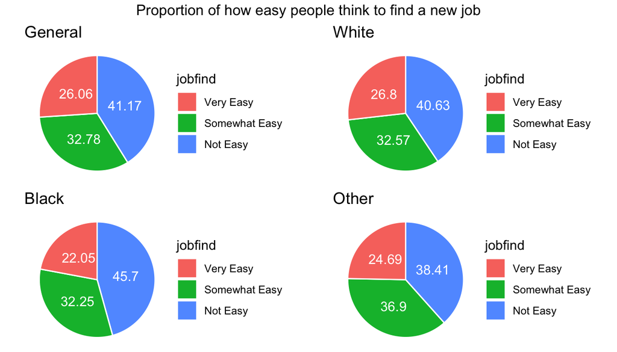

```r
gss_white <- gss %>% filter(race == "White")
gss_black <- gss %>% filter(race == "Black")
gss_other <- gss %>% filter(race == "Other")

prop_white <- as.data.frame(prop.table(table(gss_white$jobfind)))
prop_black <- as.data.frame(prop.table(table(gss_black$jobfind)))
prop_other <- as.data.frame(prop.table(table(gss_other$jobfind)))

prop_gen <- as.data.frame(prop.table(table(gss$jobfind)))
prop_gen <- prop_gen %>%
    arrange(desc(Var1)) %>%
    mutate(Freq = round(Freq*100, digits = 2))  %>%
    mutate(lab.ypos = cumsum(Freq) - 0.5*Freq)
colnames(prop_gen)[1] <- "jobfind"

pie_gen <- ggplot(prop_gen, aes(x="", y=Freq, fill=jobfind)) +
    geom_bar(width = 1, stat = "identity", color = "white") +
    coord_polar("y", start = 0) +
    geom_text(aes(y = lab.ypos, label = Freq), color = "white") +
    theme_void() +
    labs(title = "General")

# Add label position
prop_white <- prop_white %>%
    arrange(desc(Var1)) %>%
    mutate(Freq = round(Freq*100, digits = 2))  %>%
    mutate(lab.ypos = cumsum(Freq) - 0.5*Freq)
colnames(prop_white)[1] <- "jobfind"

pie_white <- ggplot(prop_white, aes(x="", y=Freq, fill=jobfind)) +
    geom_bar(width = 1, stat = "identity", color = "white") +
    coord_polar("y", start = 0) +
    geom_text(aes(y = lab.ypos, label = Freq), color = "white") +
    theme_void() +
    labs(title = "White")


# Add label position
prop_black <- prop_black %>%
    arrange(desc(Var1)) %>%
    mutate(Freq = round(Freq*100, digits = 2))  %>%
    mutate(lab.ypos = cumsum(Freq) - 0.5*Freq)
colnames(prop_black)[1] <- "jobfind"

pie_black <- ggplot(prop_black, aes(x="", y=Freq, fill=jobfind)) +
    geom_bar(width = 1, stat = "identity", color = "white") +
    coord_polar("y", start = 0) +
    geom_text(aes(y = lab.ypos, label = Freq), color = "white") +
    theme_void() +
    labs(title = "Black")



# Add label position
prop_other <- prop_other %>%
    arrange(desc(Var1)) %>%
    mutate(Freq = round(Freq*100, digits = 2))  %>%
    mutate(lab.ypos = cumsum(Freq) - 0.5*Freq)
colnames(prop_other)[1] <- "jobfind"

pie_other <- ggplot(prop_other, aes(x="", y=Freq, fill=jobfind)) +
    geom_bar(width = 1, stat = "identity", color = "white") +
    coord_polar("y", start = 0) +
    geom_text(aes(y = lab.ypos, label = Freq), color = "white") +
    theme_void() +
    labs(title = "Other")


pie_arranged <- ggarrange(pie_gen, pie_white, pie_black, pie_other, ncol=2, nrow=2)
annotate_figure(pie_arranged, top = "Proportion of how easy people think to find a new job")
```

## Part 4: Inference

Some differences of the altitude of people with various ethic background for job market has been observed in the last sectoin. Now, a statistical inference will be made to identify if there is really correlation between ethnicity and prospects of job-finding difficulty.

### Hypotheses

$$H_{0} : \textit{Ethnicity and prospects of job-finding difficulty are independent}\\
H_{1} : \textit{Ethnicity and prospects of job-finding difficulty are not independent}$$

### Conditions

1. Independence
- random sample
- $n = 18672 < 10\% * \text{US population}$
- each case only contributes to one cell in the table
2. Sample size
- each scenario has more than 5 expected cases.

### $\chi^{2}$ test of independence

As the task is to evaluate the the relationship between two categorical variables, which both has more than 2 levels, $\chi^{2}$ test of independece should be used.
$$\chi^{2}=\sum_{i=1}^{k} \frac{(O-E)^{2}}{E}$$
with $O$ is the observed proportion, $E$ is the expected proportion, which in this case is the proportion of the general population’s prospect of job market multiplied by the observed sample number of people with various ethnic background.

The degree of freedom for the $\chi^{2}$ test is:
$$d f=(R-1) \times(C-1)$$
$R$ is number of rows (3), and $C$ is numnber of columns(3).

```r
inference(y=jobfind, x=race, data=gss, type = "ht", statistic = "proportion", method = "theoretical", alternative = "greater")
```

```
## Response variable: categorical (3 levels)
## Explanatory variable: categorical (3 levels)
## Observed:
##        y
## x       Very Easy Somewhat Easy Not Easy
##   White      4063          4939     6160
##   Black       541           791     1121
##   Other       261           390      406
##
## Expected:
##        y
## x       Very Easy Somewhat Easy Not Easy
##   White 3950.4675     4969.5501 6241.982
##   Black  639.1305      804.0039 1009.866
##   Other  275.4019      346.4460  435.152
##
## H0: race and jobfind are independent
## HA: race and jobfind are dependent
## chi_sq = 40.1589, df = 4, p_value = 0
```

[figure not shown]

The result shows a chi_sq = 40.1589 with a p-value very close to 0. Hence, the null hypothesis is rejected, which leads to ethnic background and propects of job-finding difficulty are not independent. To put it in a different way, there is a correlation between ethnic background and propects of job-finding difficulty.

Here a $\chi^{2}$ test of independence is used, so there is no confidence interval constructed.